# Data1 analysis

# Data analysis and figure creation for Color Memory and Emotion Experiment on Youtube

## Introduction

This file was used to analyze data from my Color Memory and Emotion Experiment, https://www.youtube.com/watch?v=U6WmtoIuaXY.  
All materials, including consent, tasks, and debriefing can be accessed in the previous link provided. **Note**: The link may not be accessible on mobile devices. It is suggested to work on a laptop or desktop computer.

Although several variables were included. Only two were of interest to be analyzed here. The variables representing Congruence and Recall(Remember) were the 2 analyzed. These data were analyzed and presented on the poster.

### Preparing data for analysis

```r
d<-read.csv("data1.csv")
```

Let’s take a look at the data.

```r
str(d)
```

```
## 'data.frame':    34 obs. of  4 variables:
##  $ Color     : Factor w/ 3 levels "Green","Green ",..: 3 3 3 3 3 3 3 1 1 1 ...
##  $ Valence   : int  5 5 5 5 1 1 3 3 4 4 ...
##  $ Remember  : Factor w/ 2 levels "N","Y": 2 2 2 2 2 2 2 2 2 2 ...
##  $ Congruence: Factor w/ 2 levels "N","Y": 2 2 2 2 2 2 2 2 2 2 ...
```

I’m going to find how many recalled their words and how many did not recall the target words.

```r
summary(d$Remember)
```

```
##  N  Y
##  6 28
```

Let’s also do this for congruence to see how many participated in congruent and incongruent conditions

```r
summary(d$Congruence)
```

```
##  N  Y
## 16 18
```

We need to tranform the variables we will be using into factor variables.

```r
d$Remember<-as.factor(d$Remember)
d$Congruence<-as.factor(d$Congruence)
```

## Figure

To visualize the data as presented, I will create a histogram of the valence rankings as the pertain to how frequent they appear.

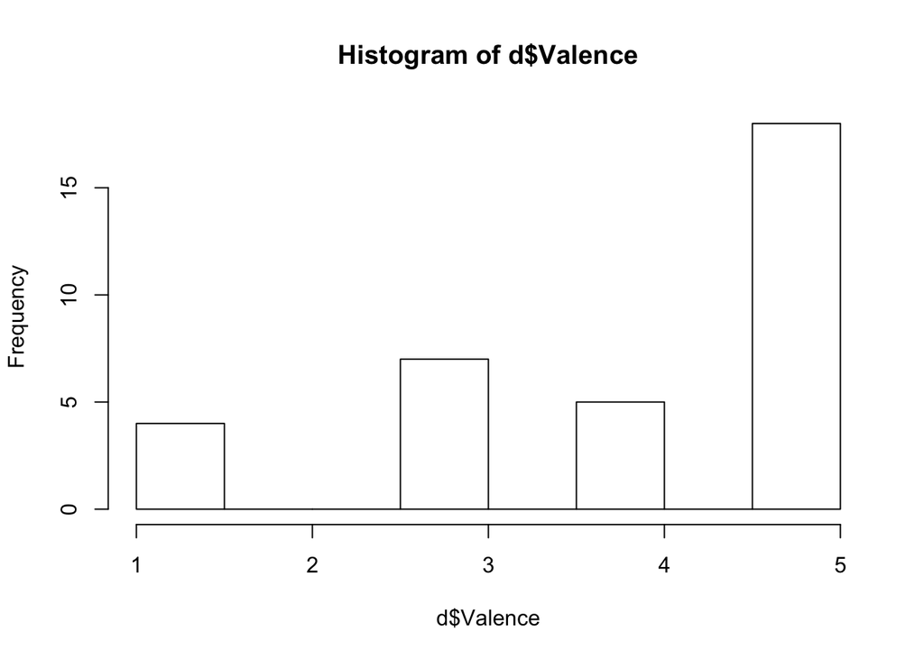

```r
hist(d$Valence)
```

```r
library(ggplot2)
```

## Primary Analysis

We will us a Chi Square test to compare counts of categorical responses between the recalled words and whether or not the participants were in a congruent condition.

```r
tab<-table(d$Remember,d$Congruence)
tab
```

```
##
##      N  Y
##   N  5  1
##   Y 11 17
```

[output not shown]

These are the frequencies in which the participants remembered the word and whether or not it was congruent.

```r
chisq.test(d$Remember,d$Remember)
```

```
##
##  Pearson's Chi-squared test with Yates' continuity correction
##
## data:  d$Remember and d$Remember
## X-squared = 27.467, df = 1, p-value = 1.598e-07
```